Находим 10 треков с максимальным количеством прослушиваний.

```python
top10_streams = df.sort_values(by='stream_count', ascending=False).head(10)

display(top10_streams[['artist_name', 'genre', 'stream_count']])

print("Исполнители в топ-10:")
print(top10_streams['artist_name'].unique())

print("\nЖанры в топ-10:")
print(top10_streams['genre'].value_counts())
```

|  | artist_name | genre | stream_count |
| --- | --- | --- | --- |
| 1528 | Grove Nova | Alternative | 43345015 |
| 36998 | Flora Quinn | Rock | 26635547 |
| 42813 | Ethereal | Pop | 26314312 |
| 21643 | SethStone | Metal | 20408155 |
| 49193 | IsleEyre | Pop | 19265301 |
| 26622 | Dean System | Hip-Hop | 17238449 |
| 45015 | Rocco Ore | R&B | 15776187 |
| 39012 | Knot Hart | R&B | 14545933 |
| 29091 | The Inks | Pop | 14507867 |
| 13635 | Prism Hart | R&B | 14367106 |

```
Исполнители в топ-10:
['Grove Nova' 'Flora Quinn' 'Ethereal' 'SethStone' 'IsleEyre'
 'Dean System' 'Rocco Ore' 'Knot Hart' 'The Inks' 'Prism Hart']

Жанры в топ-10:
genre
Pop            3
R&B            3
Alternative    1
Rock           1
Metal          1
Hip-Hop        1
Name: count, dtype: int64
```

4. Фильтрация

Оставляем только треки, выпущенные после 2024 года.

```python
tracks_after_2024 = df[df['release_year'] > 2024]

display(tracks_after_2024)
print("Количество треков после 2024 года:", tracks_after_2024.shape[0])
```

|  | track_id | track_name | artist_name | album_name | release_date | genre | duration_ms | popularity | danceability | energy | ... | popularity_category | loudness_category | key_name | mode_name | is_explicit_bool | release_quarter | is_weekend_release | log_stream_count | upbeat_score | artist_track_count |
| --- | --- | --- | --- | --- | --- | --- | --- | --- | --- | --- | --- | --- | --- | --- | --- | --- | --- | --- | --- | --- | --- |
| 6 | 305b4f13-b2ac-47e9-a6f2-d0c15934f8b6 | Skies | Knot Hart | The Ancient Tapes | 2025-07-16 | R&B | 251330 | 18 | 0.7399 | 0.4000 | ... | Low | Moderate | G | Minor | False | Q3 | False | 9.6072 | 0.5475 | 12111 |
| 14 | 7e9be073-392f-4592-bea4-8b670368087c | The Roads | Knot Hart | Oceans | 2025-11-26 | R&B | 253544 | 5 | 0.4676 | 0.4455 | ... | Low | Moderate | C | Minor | False | Q4 | False | 6.7867 | 0.4417 | 12111 |
| 17 | 6a12365c-81bd-424b-884b-2bbcc5ff620a | Liquid Streets | ElaraRain | Invisible Waves | 2025-05-22 | Pop | 199052 | 25 | 0.5858 | 0.6315 | ... | Medium | Moderate | F | Major | False | Q2 | False | 9.4172 | 0.5639 | 1111 |
| 18 | cee75c87-13b6-4af0-a17d-830be6008414 | Broken Ghosts | Sterling Zen | Blinding Shadows | 2025-01-21 | Hip-Hop | 171193 | 40 | 0.8733 | 0.7090 | ... | Medium | Loud | F | Minor | False | Q1 | False | 11.7608 | 0.7445 | 2268 |
| 24 | cfc19120-16c7-4e8c-a99e-e617973c451a | The Tears | Sterling Zen | Sacred Rain | 2025-03-18 | Folk | 233446 | 33 | 0.3071 | 0.3266 | ... | Medium | Moderate | B | Major | True | Q1 | False | 10.7252 | 0.3225 | 2268 |
| ... | ... | ... | ... | ... | ... | ... | ... | ... | ... | ... | ... | ... | ... | ... | ... | ... | ... | ... | ... | ... | ... |
| 49970 | b9cb5000-702d-449b-91ea-5bfbf0eaacc8 | Twisted Empty Floors | IsleEyre | Skies | 2025-04-09 | Pop | 278833 | 25 | 0.6097 | 0.8090 | ... | Medium | Moderate | D# | Minor | False | Q2 | False | 10.7419 | 0.6625 | 5271 |
| 49976 | 609e15e2-1385-45ff-859e-bdfb0eee7a61 | Blinding Lines | ValeGlass | Velvet Bones | 2025-11-30 | Latin | 216171 | 31 | 0.7654 | 0.6896 | ... | Medium | Loud | F | Major | True | Q4 | True | 11.6265 | 0.6584 | 981 |
| 49981 | 32a33aad-48d1-4f39-914d-374e3c9e8eb2 | Ancient Night | Knot Hart | Lost Winds | 2025-10-31 | R&B | 178343 | 11 | 0.6109 | 0.6311 | ... | Low | Loud | C | Major | False | Q4 | False | 7.2392 | 0.5838 | 12111 |
| 49987 | 7deb5a56-18ba-420e-acbd-167adaac4c4a | Dreams | Rocco Ore | Crystal | 2025-09-15 | R&B | 162654 | 16 | 0.6925 | 0.3973 | ... | Low | Moderate | C# | Major | False | Q3 | False | 7.8883 | 0.4859 | 1709 |
| 49995 | 38913908-e3ab-42a2-9a97-2d1847c21e3b | Flames | Luna Ink | The Shattered Tapes | 2025-02-27 | Hip-Hop | 249380 | 6 | 0.7338 | 0.8172 | ... | Low | Loud | C# | Major | False | Q1 | False | 6.2005 | 0.7545 | 577 |

8318 rows × 33 columns

```
Количество треков после 2024 года: 8318
```

Основные статистические показатели

```python
pop_stats = df['popularity'].agg(['mean', 'median', 'min', 'max', 'std'])

display(pop_stats)

print(f"Среднее значение popularity: {pop_stats['mean']:.2f}")
print(f"Медиана popularity: {pop_stats['median']:.2f}")
print(f"Минимум popularity: {pop_stats['min']}")
print(f"Максимум popularity: {pop_stats['max']}")
print(f"Стандартное отклонение popularity: {pop_stats['std']:.2f}")
```

```
mean      28.136820
median    26.000000
min        0.000000
max       92.000000
std       15.999501
Name: popularity, dtype: float64
```

```
Среднее значение popularity: 28.14
Медиана popularity: 26.00
Минимум popularity: 0.0
Максимум popularity: 92.0
Стандартное отклонение popularity: 16.00
```

Мода

```python
genre_mode = df['genre'].mode()
year_mode = df['release_year'].mode()

print("Мода для genre:")
print(genre_mode)

print("\nМода для release_year:")
print(year_mode)
```

```
Мода для genre:
0    R&B
Name: genre, dtype: object

Мода для release_year:
0    2024
Name: release_year, dtype: int64
```

Гистограмма

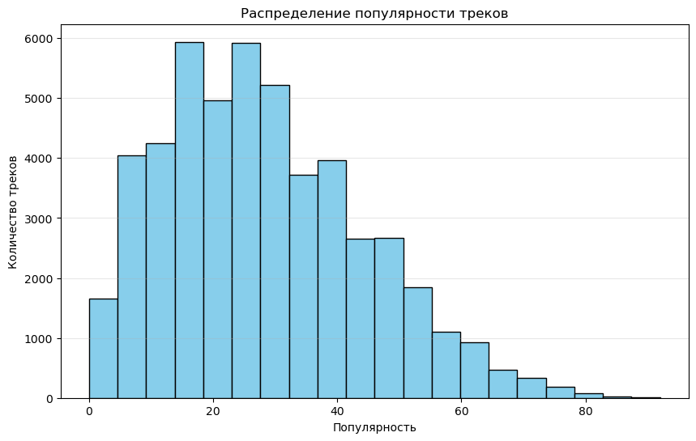

```python
plt.figure(figsize=(10, 6))
plt.hist(df['popularity'], bins=20, color='skyblue', edgecolor='black')
plt.title('Распределение популярности треков')
plt.xlabel('Популярность')
plt.ylabel('Количество треков')
plt.grid(axis='y', alpha=0.3)
plt.show()
```

Дополнительно можно посчитать диапазон основной части значений:

```python
q1 = df['popularity'].quantile(0.25)
q3 = df['popularity'].quantile(0.75)

print(f"25-й процентиль: {q1}")
print(f"75-й процентиль: {q3}")
print(f"Основная часть значений примерно в диапазоне: {q1}–{q3}")
```

```
25-й процентиль: 16.0
75-й процентиль: 39.0
Основная часть значений примерно в диапазоне: 16.0–39.0
```

8. Ответы на контрольные вопросы
1. Что такое DataFrame?

DataFrame — это двумерная таблица данных в библиотеке Pandas. Она состоит из строк и столбцов, похожа на таблицу Excel или SQL-таблицу. В DataFrame могут храниться разные типы данных: числа, строки, даты, логические значения. У строк и столбцов есть индексы и названия. В данной работе DataFrame df содержит информацию о треках Spotify. 2. Что такое признак (Feature)? Признак — это отдельная характеристика объекта, то есть столбец в таблице данных. Например, в нашем датасете признаками являются artist_name, genre, popularity, stream_count, release_year, tempo, duration_ms и другие. По признакам мы анализируем объекты: сравниваем, фильтруем, строим графики и ищем закономерности. 3. Чем среднее арифметическое отличается от медианы? Среднее арифметическое — это сумма всех значений, делённая на их количество. Оно показывает «среднее» значение, но сильно зависит от выбросов. Медиана — это значение, которое находится в середине упорядоченного ряда. Она делит данные так, что 50% значений меньше медианы и 50% больше. Медиана устойчива к выбросам. Если данные распределены симметрично, среднее и медиана близки. Если есть сильно выделяющиеся значения, медиана лучше показывает типичное значение. 4. Что показывает гистограмма? Гистограмма показывает распределение числового признака. По оси X откладываются интервалы значений, а по оси Y — частота или количество значений, попавших в каждый интервал. С помощью гистограммы можно увидеть: в каком диапазоне сосредоточена основная часть значений; есть ли пики и провалы; симметрично ли распределение; есть ли редкие значения и выбросы. 6. Для чего нужна фильтрация данных? Фильтрация нужна для отбора нужных строк по определённому условию. Например, можно оставить только треки после 2024 года, только жанр Pop или только треки с популярностью выше 50. Фильтрация помогает анализировать не весь датасет сразу, а конкретную группу объектов, убирать лишние данные и находить закономерности внутри нужной части таблицы.